# hw

### Linear Regression

In this homework we will walk through how to do linear regression from scratch using numpy.

**Due 3/7**

#### Part 1

The first thing we need to do is implement the standard error measures used in regression. You can find the definitions of *Mean Absolute Error* (MAE) and *Root Mean Squared Error* (RMSE) [here](https://www.dataquest.io/blog/understanding-regression-error-metrics/). The definition of the Coefficient of Determination (R2) can be found [here](https://en.wikipedia.org/wiki/Coefficient_of_determination). Implement them in the following cell.

```python
def MAE(g,y):
    """g is the predicted outcomes and y is the actual outcomes"""

def RMSE(g,y):
    """g is the predicted outcomes and y is the actual outcomes"""

def R2(g,y):
    """g is the predicted outcomes and y is the actual outcomes"""
```

### Make some data

Now we'll create some artificial data to practice on. We're generating the data by adding noise to the usual square root function. The noise is sampled from a normal distribution.

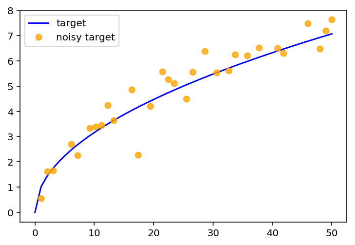

```python
import numpy as np
import matplotlib.pyplot as plt


x = np.linspace(0,50,50) ## The domain
N = 30   ## 30 sample points
np.random.seed(22)  # so we get the same random stuff
shuff = np.random.permutation(len(x))
x_pts = sorted(x[shuff][:N])  ## Pick N points at random from the domain

f = np.sqrt   #The target function (no noise yet)

sigma = 1/2
noise = np.random.randn(N)*sigma  ## Noise sampled from the normal distribution with sd=sigma

f_noisy = f(x_pts) + noise   ## Noisy data

plt.plot(x,f(x),label="target",c='blue')
plt.plot(x_pts,f_noisy,'o',label="noisy target",alpha=0.8,c='orange')
plt.legend()
plt.show()
```

### Fitting and predicting

#### Part 2

Now implement the two functions below. The `linear_fit` function returns the weight vector `w` found by the linear regression learning algorithm. Please implement the version that uses the normal equations. You can find the definition of the normal equations (and their derivation) many places online or in the book. [Here](https://eli.thegreenplace.net/2014/derivation-of-the-normal-equation-for-linear-regression/) is an example (they use $\theta$ for what we call $w$). Another example is given in the PDF I included with this homework. Note that numpy can compute the pseudo-inverse directly with `np.linalg.pinv(X)`.

```python
def linear_fit(X,y):

def linear_predict(X,w):
    """Returns a vector of predictions g where g[i] is the prediction for the ith row of X"""
```

### Check your work

Now you can check the correctness of the code you wrote.

The output should look something like this:

[figure not shown]

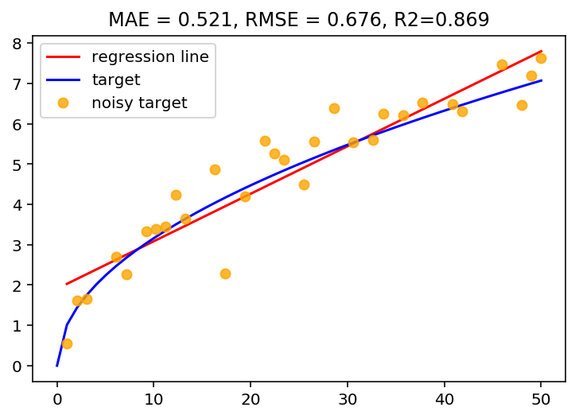

```python
# Work check

X = np.ones(N*2).reshape(N,2)
X[:,1] = x_pts
y = f_noisy

w = linear_fit(X,y)
g = linear_predict(X,w)


plt.plot(x_pts,g,label="regression line",c='red')
plt.plot(x,f(x),label="target",c='blue')
plt.plot(x_pts,f_noisy,'o',label="noisy target",alpha=0.8,c='orange')
plt.title(f"MAE = {MAE(g,y):0.3}, RMSE = {RMSE(g,y):0.3}, R2={R2(g,y):0.3}")

plt.legend()

plt.show()
```

### What's so linear about it?

An important thing to understand about linear regression is that it is linear *in the weights* not in the data.

Linear regression finds the `w` that minimizes the mean squared error of `g = X.dot(w)` and `y`. This says nothing about what the columns of `X` are. They could in fact be *non-linear* functions of the data.

### Work check

[figure not shown]

[figure not shown]

```python
## Work check
#X = np.ones(N*3).reshape(N,3)
x_pts = np.array(x_pts)


y = f_noisy


w = linear_fit(X,y)
g = linear_predict(X,w)


plt.plot(x_pts,g,label="regression curve",c='red',marker='o')
plt.plot(x,f(x),label="target",c='blue')
plt.plot(x_pts,f_noisy,'o',label="noisy target",alpha=0.8,c='orange')
plt.legend()
plt.title(f"MAE = {MAE(g,y):0.3}, RMSE = {RMSE(g,y):0.3}, R2={R2(g,y):0.3}")
plt.savefig("party3.png")
plt.show()
```

### Polynomial models

Lets experiment with using polynomial models to fit the data.

The code below will fit some synthetic data with polynomials of degree 1,4,7,10 and 13.

#### Part 4

a. Which polynomial has the best R2 score (closest to 1)?

b. Which degree polynomial would you expect to generalize the best to new data points?

```
0 1
1 4
2 7
3 10
4 13
```

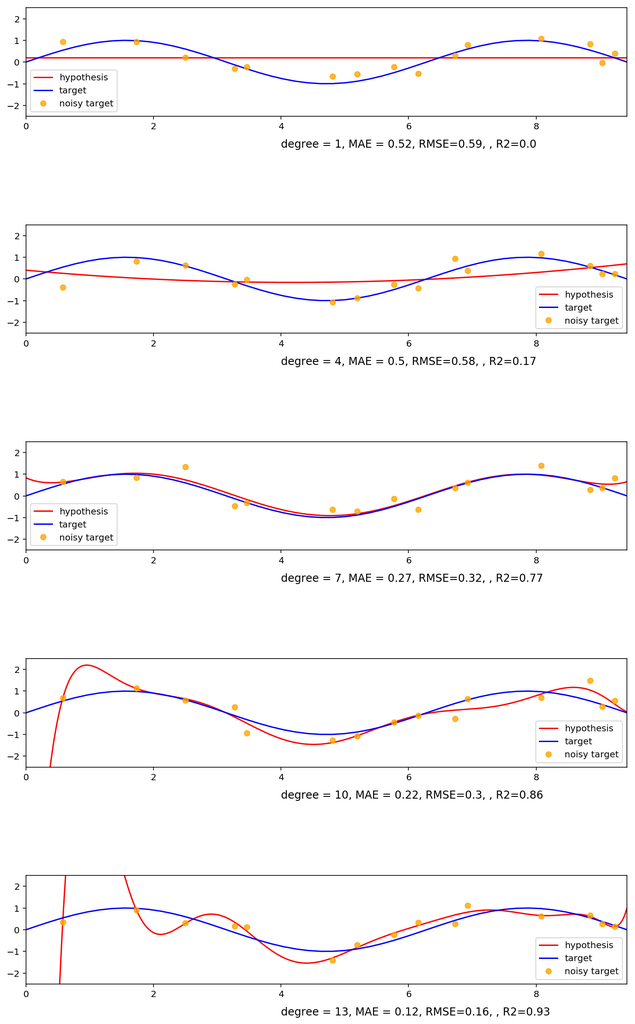

```python
x = np.linspace(0,3*np.pi,50)
N = 15
shuff = np.random.permutation(len(x))
x_pts = np.array(sorted(x[shuff][:N]))

numfigs = 5
fig,axes = plt.subplots(5,1,figsize=(12,4*numfigs))

plt.subplots_adjust(hspace=1)

wt_by_deg = dict()

for i,deg in enumerate(range(1,numfigs*3+1,3)):
    print(i,deg)
    X = np.ones(N*deg).reshape(N,deg)
    for j in range(1,deg):
        X[:,j] = x_pts**j


    noise = np.random.randn(N)
    y = np.sin(x_pts)+ noise/3


    w = linear_fit(X,y)
    g = linear_predict(X,w)


    wt_by_deg[deg] = tuple(w)

    xx = np.linspace(0,np.pi*3,10000)
    h = np.zeros(len(xx))
    for j in range(deg):
        h += w[j]*xx**j

    axes[i].plot(xx,h,label="hypothesis",c='red')

    axes[i].plot(x,np.sin(x),label="target",c='blue')
    axes[i].plot(x_pts,y,'o',label="noisy target",alpha=0.8,c='orange')
    axes[i].legend()
    ymax = 2.5
    ymin = -2.5
    axes[i].axis([0,3*np.pi,ymin,ymax])

    text = axes[i].text(4,ymin-1.3,f"degree = {deg}, MAE = {MAE(g,y):0.2}, RMSE={RMSE(g,y):0.2}, , R2={R2(g,y):0.2}", size=12,
    verticalalignment='center')
plt.show()
```

### Checking out of sample error

Now we examine the polynomials that were learned on the "orange" points shown above, and see how they do on new points (in purple) drawn from the same distribution.

#### Part 5

a. Which polynomial does the best on the new data?

b. Which polynomial does the worst?

c. Why did the high degree polynomial not do well on new data?

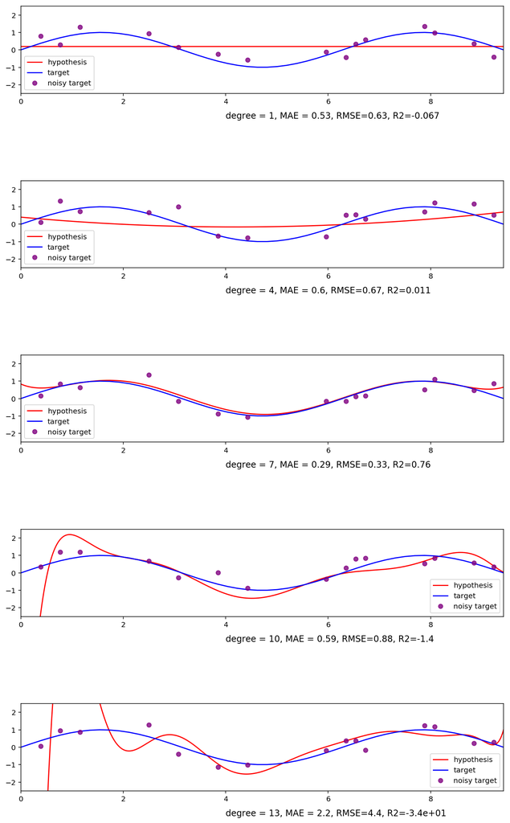

```python
x = np.linspace(0,3*np.pi,50)
N = 15
shuff = np.random.permutation(len(x))
x_pts = np.array(sorted(x[shuff][:N]))

numfigs = 5
fig,axes = plt.subplots(5,1,figsize=(12,4*numfigs))

plt.subplots_adjust(hspace=1)


for i,deg in enumerate(range(1,numfigs*3+1,3)):
    X = np.ones(N*deg).reshape(N,deg)
    for j in range(1,deg):
        X[:,j] = x_pts**j


    noise = np.random.randn(N)
    y = np.sin(x_pts)+ noise/3

    w = wt_by_deg[deg]


    g = linear_predict(X,w)

    xx = np.linspace(0,np.pi*3,10000)
    h = np.zeros(len(xx))
    for j in range(deg):
        h += w[j]*xx**j

    axes[i].plot(xx,h,label="hypothesis",c='red')

    axes[i].plot(x,np.sin(x),label="target",c='blue')
    axes[i].plot(x_pts,y,'o',label="noisy target",alpha=0.8,c='purple')
    axes[i].legend()
    ymax = 2.5
    ymin = -2.5
    axes[i].axis([0,3*np.pi,ymin,ymax])

    text = axes[i].text(4,ymin-1.3,f"degree = {deg}, MAE = {MAE(g,y):0.2}, RMSE={RMSE(g,y):0.2}, R2={R2(g,y):0.2}", size=12,
    verticalalignment='center')
plt.show()
```

#### Part 6

Below is part of a function that produces a test/train split on a dataset $\mathcal{D}$.

Fill in the missing parts of the function in the following way using array slicing.

`X_train` should be the first "`cutoff`" many elements in the shuffled matrix `X2`.

`X_test` should be the remaining elements in `X2`.

`y_train` should be the first "`cutoff`" many elements in the shuffled matrix `y2`.

`y_test` should be the remaining elements in `y2`.

```python
def test_train_split(X,y,train_percent=0.8,rand_seed=42):
    np.random.seed(rand_seed)
    cutoff = int(train_percent*X.shape[0])
    shuff = np.random.permutation(X.shape[0])
    X2 = X[shuff]
    y2 = y[shuff]
   ##### Your code
    return X_train,X_test,y_train,y_test
```

#### Part 7

Suppose we have a dataset $\mathcal{D}$ in a regression problem.

1. What will happen to the in-sample error of linear regression using polynomials of degree $d$ as $d \to \infty$?
2. What will happen to the out-of-sample error of linear regression as $d$ increases?

You can use the output of the code below to help you form your answer.

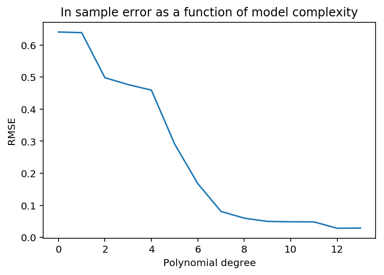

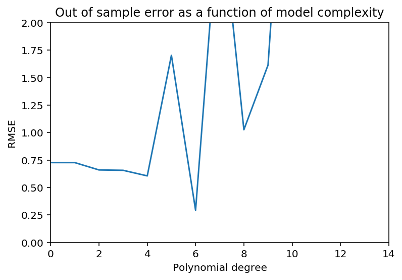

```python
xmin,xmax = 0,4*np.pi
x = np.linspace(xmin,xmax,1000)
D = 14

N = 100
shuff = np.random.permutation(len(x))
x_pts = np.array(sorted(x[shuff][:N]))

K = 200
train_vals = np.zeros(D*K).reshape(K,D)
test_vals = np.zeros(D*K).reshape(K,D)
noise = np.random.randn(N)
y = np.sin(x_pts)+ noise/7

for k in range(K):
    shuff = np.random.permutation(len(x))
    x_pts = np.array(sorted(x[shuff][:N]))
    noise = np.random.randn(N)
    y = np.sin(x_pts)+ noise/7
    for i,deg in enumerate(range(D)):
        X = np.ones(N*deg).reshape(N,deg)
        for j in range(1,deg):
            X[:,j] = x_pts**j
        X_train,X_test,y_train,y_test = test_train_split(X,y,0.13)

        w = linear_fit(X_train,y_train)

        g_train = linear_predict(X_train,w)
        g_test = linear_predict(X_test,w)

        r_train = RMSE(g_train,y_train)
        r_test = RMSE(g_test,y_test)
        train_vals[k][i] = r_train
        test_vals[k][i] = r_test

tr_vals = np.mean(train_vals,axis=0)
te_vals = np.mean(test_vals,axis=0)

plt.plot(range(D),tr_vals)
plt.title("In sample error as a function of model complexity")
plt.xlabel("Polynomial degree")
plt.ylabel("RMSE")
plt.show()
plt.title("Out of sample error as a function of model complexity")
plt.plot(range(D),te_vals)
plt.xlabel("Polynomial degree")
plt.ylabel("RMSE")

plt.axis([0,D,0,2])
plt.show()
```

#### Part 8

In your answer to part 7 you hopefully observed that training error should strictly decrease as the degree of the hypothesis polynomials increases. That is because any high degree polynomial can "simulate" a lower degree polynomial by making it's high order coefficients zero. Thus nothing is lost and something might be gained by increasing the degree.

But the code below shows that in-sample error actually starts to increase on our dataset for polynomials of very high degree. Why do you think this happens?

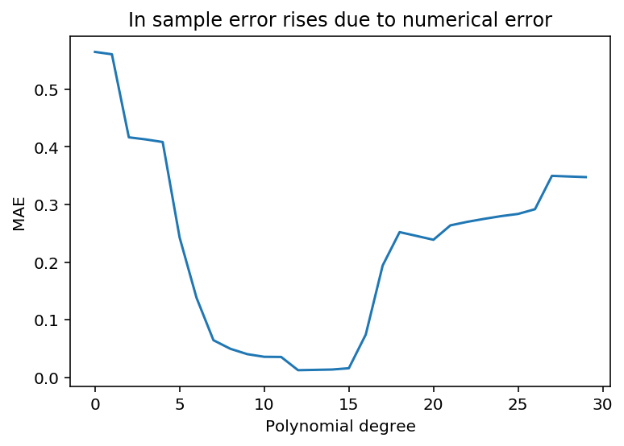

```python
## Numerical error

xmin,xmax = 0,4*np.pi
x = np.linspace(xmin,xmax,1000)
D = 30

N = 100
shuff = np.random.permutation(len(x))
x_pts = np.array(sorted(x[shuff][:N]))

K = 200
train_vals = np.zeros(D*K).reshape(K,D)
test_vals = np.zeros(D*K).reshape(K,D)
noise = np.random.randn(N)
y = np.sin(x_pts)+ noise/7

for k in range(K):
    shuff = np.random.permutation(len(x))
    x_pts = np.array(sorted(x[shuff][:N]))
    noise = np.random.randn(N)
    y = np.sin(x_pts)+ noise/7
    for i,deg in enumerate(range(D)):
        X = np.ones(N*deg).reshape(N,deg)
        for j in range(1,deg):
            X[:,j] = x_pts**j
        X_train,X_test,y_train,y_test = test_train_split(X,y,0.13)

        w = linear_fit(X_train,y_train)

        g_train = linear_predict(X_train,w)
        g_test = linear_predict(X_test,w)

        r_train = MAE(g_train,y_train)
        r_test = MAE(g_test,y_test)
        train_vals[k][i] = r_train
        test_vals[k][i] = r_test

tr_vals = np.mean(train_vals,axis=0)
te_vals = np.mean(test_vals,axis=0)

plt.plot(range(D),tr_vals)
plt.title("In sample error rises due to numerical error")
plt.xlabel("Polynomial degree")
plt.ylabel("MAE")

#plt.axis([0,D,0,2])
plt.show()
```

#### Part 9

Adjust the `deg` (degree) variable in the code below such that the hypothesis space best suits the data and target function. The graphic should be helpful. Consider whether you want to revise your answer for Part 7 pt 2.

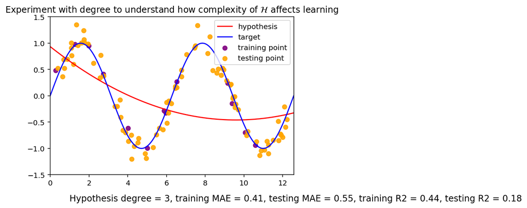

```python
shuff = np.random.permutation(len(x))
x_pts = np.array(sorted(x[shuff][:N]))

deg = 3  ## The degree of the polynomials in the hypothesis space

noise = np.random.randn(N)
y = np.sin(x_pts) + noise/7
yy = np.sin(x)

X = np.ones(N*deg).reshape(N,deg)
for j in range(1,deg):
    X[:,j] = x_pts**j

X_train,X_test,y_train,y_test = test_train_split(X,y,0.13)




w = linear_fit(X_train,y_train)
g_train = linear_predict(X_train,w)
g_test = linear_predict(X_test,w)

xx = np.linspace(0,xmax,10000)
h = np.zeros(len(xx))
for j in range(deg):
    h += w[j]*xx**j

plt.plot(xx,h,label="hypothesis",c='red')

plt.plot(x,yy,label="target",c='blue')
plt.title(r"Experiment with degree to understand how complexity of $\mathcal{H}$ affects learning")
plt.scatter(X_train[:,1],y_train,c='purple',label="training point",alpha=0.9)
plt.scatter(X_test[:,1],y_test,c='orange',label="testing point",alpha=0.9)
plt.legend()

ymax = 1.5
ymin = -1.5#np.min(X[:,1])*1.15
plt.axis([xmin,xmax,ymin,ymax])
plt.text((xmax-xmin)//8,ymin*1.3,f"Hypothesis degree = {deg}, training MAE = {MAE(g_train,y_train):0.2}, testing MAE = {MAE(g_test,y_test):0.2}, training R2 = {R2(g_train,y_train):0.2}, testing R2 = {R2(g_test,y_test):0.2}", size=12,
    verticalalignment='center')
plt.show()
```

### Learning Curves

In the above exercises we fixed a dataset and explored what happens as we vary the complexity of the hypothesis class $\mathcal{H}$.

Now we will fix a hypothesis class $\mathcal{H}$ and explore what happens to training and testing error as the number of datapoints increases. This is known as a [Learning Curve](https://www.coursera.org/lecture/machine-learning/learning-curves-Kont7).

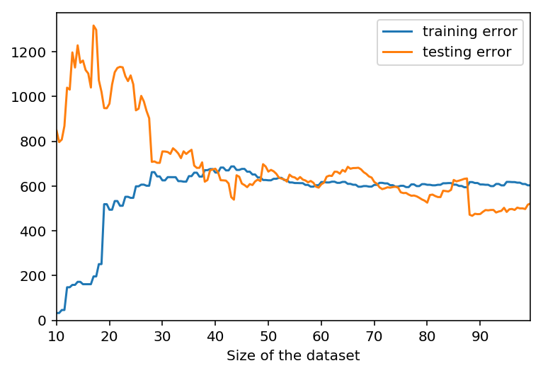

```python
x = np.linspace(0,17*np.pi,2000)
N = 200
shuff = np.random.permutation(len(x))
x_pts = np.array(sorted(x[shuff][:N]))

deg =6
X = np.ones(N*deg).reshape(N,deg)
for j in range(1,deg):
    X[:,j] = x_pts**j

shuff = np.random.permutation(N)
X = X[shuff]


noise = np.random.randn(N)
y = np.sin(x_pts)*x_pts**2 + noise
y2 = y[shuff]

values = []
for m in range(10,N):
    X_train = X[:int(m*0.5)]
    X_test = X[int(m*0.5):m]

    y_train = y2[:int(m*0.5)]
    y_test = y2[int(m*0.5):m]



    w = linear_fit(X_train,y_train)


    g_train = linear_predict(X_train,w)
    g_test = linear_predict(X_test,w)

    r_train = MAE(g_train,y_train)
    r_test = MAE(g_test,y_test)
    values.append([m,r_train,r_test])

values = np.array(values)
plt.plot(values[:,0]/2,values[:,1],label="training error")
plt.plot(values[:,0]/2,values[:,2],label="testing error")
xmin = np.min(values[:,0])
xmax = np.max(values[:,0])
ymin = 0
ymax = np.max(values[:,1])*2
plt.axis([xmin,xmax/2,ymin,ymax])
plt.xlabel("Size of the dataset")
plt.legend()
plt.show()
```

### That looks a bit rough...

The shape of the above curves depend on random choices and may not look quite like the ideal.

The picture should be approximately this:

[figure not shown]

In the code below we average the above experiment over $K=200$ runs and get something that looks more appropriate.

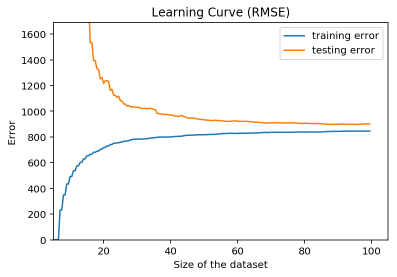

```python
K = 200
testvals = np.zeros((N-10)*K).reshape(K,N-10)
trainvals = np.zeros((N-10)*K).reshape(K,N-10)

for k in range(K):
    shuff = np.random.permutation(N)
    X = X[shuff]
    y = y[shuff]
    for m in range(10,N):
        X_train = X[:int(m*0.5)]
        X_test = X[int(m*0.5):m]

        y_train = y[:int(m*0.5)]
        y_test = y[int(m*0.5):m]




        w = linear_fit(X_train,y_train)


        g_train = linear_predict(X_train,w)
        g_test = linear_predict(X_test,w)

        r_train = RMSE(g_train,y_train)
        r_test = RMSE(g_test,y_test)
        testvals[k,m-10] = r_test
        trainvals[k,m-10] = r_train
testy = np.mean(testvals,axis=0)
trainy = np.mean(trainvals,axis=0)
plt.plot(np.arange(10,N)/2,trainy,label="training error")
plt.plot(np.arange(10,N)/2,testy,label="testing error")
xmin = 5
xmax = N/2+5
ymin = 0
ymax = np.max(trainy)*2
plt.axis([xmin,xmax,ymin,ymax])
plt.xlabel("Size of the dataset")
plt.ylabel("Error")
plt.legend()
plt.title("Learning Curve (RMSE)")
plt.show()
```

### Part 10

1. What does the learning curve look like when the hypothesis class is too complex for the target function and the amount of data?
2. What does the learning curve look like when the hypothesis class is too simple for the target function and the amount of data?
3. What does the learning curve look like if the complexity of the hypothesis class is appropriate to the problem?
4. Why does test error go down and train error go up?

### Regression meets classification

In this final section we connect regression and classification.

First we reproduce the linearly separable dataset that we used in HW 2.

Then we embed that data in 3D space by making the $z$-coordinate of each data point 1 for positive examples, and -1 for negative examples.

Finally we fit this 3D data with a plane using linear regression.

All of this is shown in the plot way down below.

#### Part 11

How can this regression plane $z = a+bx+cy$ be used to help classify new data points?

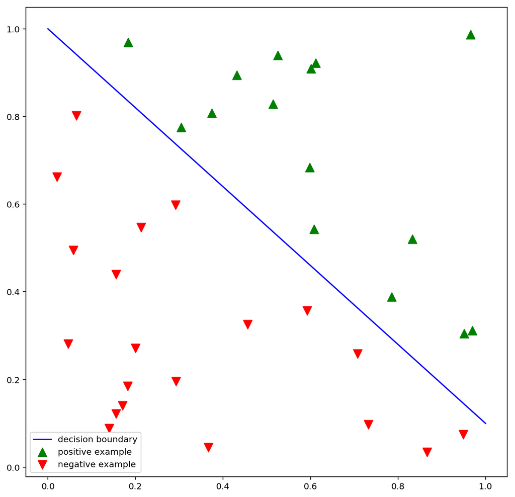

```python
## Producing synthetic data
"""
In this cell we create 35 points at random.
We separate them with a line to create linearly separable data.
The data is stored in the points array.
Note that the first column of the points array is a "bias" column of all ones.
The "line _coef" (coefficients) variable works like this:
    if line_coef = (a,b,c)
    then this describes the line
    0 = a + bx + cy
This line can be thought of as the intersection of the plane
    z = a + bx + cy
with the xy plane.
Observe that in
    0 = a + bx + cy
there are really only two degrees of freedom, because we can divide everything by c to get

    0 = A + Bx + y
where A = a/c and B = b/c.
(This assumes c != 0, but this assumption will almost always be true.)
"""

import numpy as np
import matplotlib.pyplot as plt

N = 35 # number of points
np.random.seed(42)  # So that everyone has the same "random" points
points = np.zeros(3*N).reshape(N,3)
points[:,1] = np.random.rand(N) #random x-coordinates
points[:,2] = np.random.rand(N) #random y-coordinates
points[:,0] = np.ones(N)        #bias column

line_coef = (-1,0.9,1)          #this line will define whether a point is a positive or negative example
pos = points.dot(line_coef) >= 0  # positive examples are above the line
neg = ~pos   # negative examples are below the line
"""
Question:  do you understand what pos and neg are, and how they work?
           you might want to print them out and experiment with them.
           we use them to select out certain rows of a numpy array.
           if this is confusing read the section here about
           Boolean or "mask" index arrays:
           https://docs.scipy.org/doc/numpy-1.10.0/user/basics.indexing.html
"""


x = np.linspace(0,1)                # domain of decision boundary line
y = -line_coef[1]*x - line_coef[0]  # this is the decision boundary line

"""
A note about colors... I used "green" for "positive example" and "red" for "negative example".
If you happen to be red green colorblind (like 8% of all men) then please feel free to change the colors.
"""

plt.figure(1,figsize=(10,10))
plt.scatter(points[pos,1],points[pos,2],c='green',marker="^",s=100,label="positive example")  #plot positive examples
plt.scatter(points[neg,1],points[neg,2],c='red',marker="v",s=100,label="negative example")  #plot negative examples
plt.plot(x,y,'b',label="decision boundary")  #plot linear separator
plt.legend()
plt.show()
```

```python
y = np.ones(N)
y[neg] = -1
y[pos] = 1
X = points

w = linear_fit(X,y)
X.shape
Pos =X[pos]
Neg = X[neg]
```

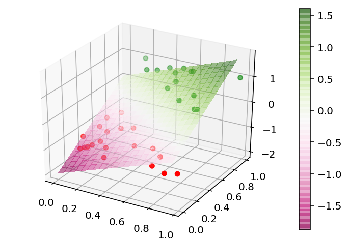

```python
from mpl_toolkits.mplot3d import Axes3D
import matplotlib.pyplot as plt
from matplotlib import cm
from matplotlib.ticker import LinearLocator, FormatStrFormatter
import numpy as np


fig = plt.figure()
#ax = fig.gca(projection='3d')

ax = plt.axes(projection='3d')


# Make data.
XX = np.arange(0, 1, 0.05)
YY = np.arange(0, 1, 0.05)
XX, YY = np.meshgrid(XX, YY)

w = linear_fit(X,y)

Z = w[0]+w[1]*XX+w[2]*YY

surf = ax.plot_surface(XX, YY, Z, cmap=cm.PiYG,
                       linewidth=0, antialiased=False,alpha=0.5)


# Data for three-dimensional scattered points
zdata = np.ones(Pos.shape[0])
xdata = Pos[:,1]
ydata = Pos[:,2]
ax.scatter3D(xdata, ydata, zdata, c='green');

zdata = -1*np.ones(Neg.shape[0])
xdata = Neg[:,1]
ydata = Neg[:,2]
ax.scatter3D(xdata, ydata, zdata, c='red');
fig.colorbar(surf)
plt.show()
```

### Linear Regression

In this homework we will walk through how to do linear regression from scratch using numpy.

**Due 3/7**

#### Part 1

The first thing we need to do is implement the standard error measures used in regression. You can find the definitions of *Mean Absolute Error* (MAE) and *Root Mean Squared Error* (RMSE) [here](https://www.dataquest.io/blog/understanding-regression-error-metrics/). The definition of the Coefficient of Determination (R2) can be found [here](https://en.wikipedia.org/wiki/Coefficient_of_determination). Implement them in the following cell.

```python
def MAE(g,y):
    """g is the predicted outcomes and y is the actual outcomes"""

def RMSE(g,y):
    """g is the predicted outcomes and y is the actual outcomes"""

def R2(g,y):
    """g is the predicted outcomes and y is the actual outcomes"""
```

### Make some data

Now we'll create some artificial data to practice on. We're generating the data by adding noise to the usual square root function. The noise is sampled from a normal distribution.

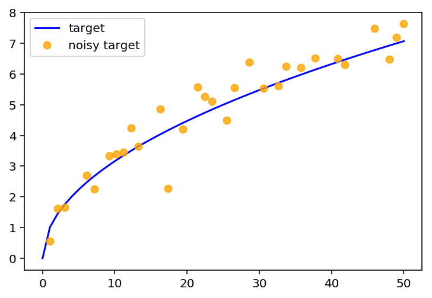

```python
import numpy as np
import matplotlib.pyplot as plt


x = np.linspace(0,50,50) ## The domain
N = 30   ## 30 sample points
np.random.seed(22)  # so we get the same random stuff
shuff = np.random.permutation(len(x))
x_pts = sorted(x[shuff][:N])  ## Pick N points at random from the domain

f = np.sqrt   #The target function (no noise yet)

sigma = 1/2
noise = np.random.randn(N)*sigma  ## Noise sampled from the normal distribution with sd=sigma

f_noisy = f(x_pts) + noise   ## Noisy data

plt.plot(x,f(x),label="target",c='blue')
plt.plot(x_pts,f_noisy,'o',label="noisy target",alpha=0.8,c='orange')
plt.legend()
plt.show()
```

### Fitting and predicting

#### Part 2

Now implement the two functions below. The `linear_fit` function returns the weight vector `w` found by the linear regression learning algorithm. Please implement the version that uses the normal equations. You can find the definition of the normal equations (and their derivation) many places online or in the book. [Here](https://eli.thegreenplace.net/2014/derivation-of-the-normal-equation-for-linear-regression/) is an example (they use $\theta$ for what we call $w$). Another example is given in the PDF I included with this homework. Note that numpy can compute the pseudo-inverse directly with `np.linalg.pinv(X)`.

```python
def linear_fit(X,y):

def linear_predict(X,w):
    """Returns a vector of predictions g where g[i] is the prediction for the ith row of X"""
```

### Check your work

Now you can check the correctness of the code you wrote.

The output should look something like this:

[figure not shown]

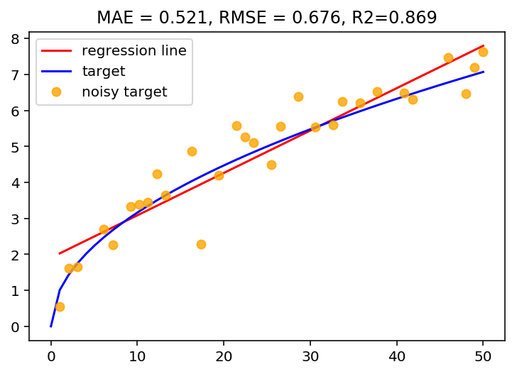

```python
# Work check

X = np.ones(N*2).reshape(N,2)
X[:,1] = x_pts
y = f_noisy

w = linear_fit(X,y)
g = linear_predict(X,w)


plt.plot(x_pts,g,label="regression line",c='red')
plt.plot(x,f(x),label="target",c='blue')
plt.plot(x_pts,f_noisy,'o',label="noisy target",alpha=0.8,c='orange')
plt.title(f"MAE = {MAE(g,y):0.3}, RMSE = {RMSE(g,y):0.3}, R2={R2(g,y):0.3}")

plt.legend()

plt.show()
```

### What's so linear about it?

An important thing to understand about linear regression is that it is linear *in the weights* not in the data.

Linear regression finds the `w` that minimizes the mean squared error of `g = X.dot(w)` and `y`. This says nothing about what the columns of `X` are. They could in fact be *non-linear* functions of the data.

### Work check

[figure not shown]

[figure not shown]

```python
## Work check
#X = np.ones(N*3).reshape(N,3)
x_pts = np.array(x_pts)


y = f_noisy


w = linear_fit(X,y)
g = linear_predict(X,w)


plt.plot(x_pts,g,label="regression curve",c='red',marker='o')
plt.plot(x,f(x),label="target",c='blue')
plt.plot(x_pts,f_noisy,'o',label="noisy target",alpha=0.8,c='orange')
plt.legend()
plt.title(f"MAE = {MAE(g,y):0.3}, RMSE = {RMSE(g,y):0.3}, R2={R2(g,y):0.3}")
plt.savefig("party3.png")
plt.show()
```

### Polynomial models

Lets experiment with using polynomial models to fit the data.

The code below will fit some synthetic data with polynomials of degree 1,4,7,10 and 13.

#### Part 4

a. Which polynomial has the best R2 score (closest to 1)?

b. Which degree polynomial would you expect to generalize the best to new data points?

```
0 1
1 4
2 7
3 10
4 13
```

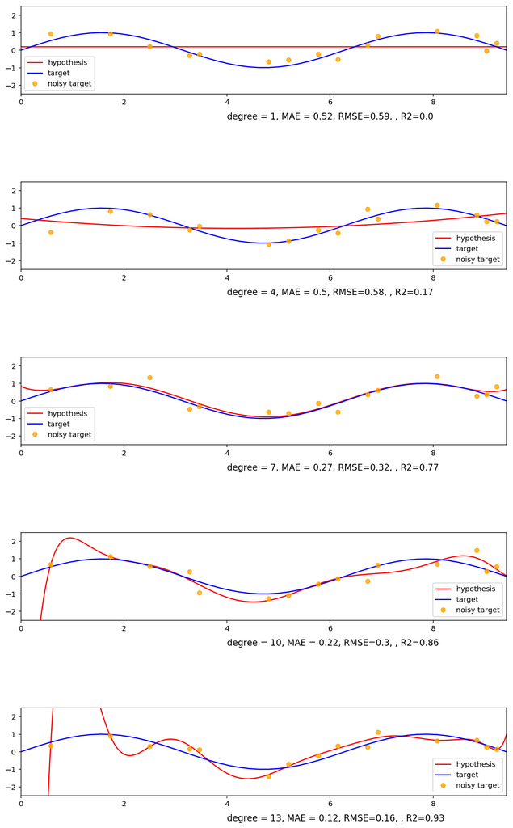

```python
x = np.linspace(0,3*np.pi,50)
N = 15
shuff = np.random.permutation(len(x))
x_pts = np.array(sorted(x[shuff][:N]))

numfigs = 5
fig,axes = plt.subplots(5,1,figsize=(12,4*numfigs))

plt.subplots_adjust(hspace=1)

wt_by_deg = dict()

for i,deg in enumerate(range(1,numfigs*3+1,3)):
    print(i,deg)
    X = np.ones(N*deg).reshape(N,deg)
    for j in range(1,deg):
        X[:,j] = x_pts**j


    noise = np.random.randn(N)
    y = np.sin(x_pts)+ noise/3


    w = linear_fit(X,y)
    g = linear_predict(X,w)


    wt_by_deg[deg] = tuple(w)

    xx = np.linspace(0,np.pi*3,10000)
    h = np.zeros(len(xx))
    for j in range(deg):
        h += w[j]*xx**j

    axes[i].plot(xx,h,label="hypothesis",c='red')

    axes[i].plot(x,np.sin(x),label="target",c='blue')
    axes[i].plot(x_pts,y,'o',label="noisy target",alpha=0.8,c='orange')
    axes[i].legend()
    ymax = 2.5
    ymin = -2.5
    axes[i].axis([0,3*np.pi,ymin,ymax])

    text = axes[i].text(4,ymin-1.3,f"degree = {deg}, MAE = {MAE(g,y):0.2}, RMSE={RMSE(g,y):0.2}, , R2={R2(g,y):0.2}", size=12,
    verticalalignment='center')
plt.show()
```

### Checking out of sample error

Now we examine the polynomials that were learned on the "orange" points shown above, and see how they do on new points (in purple) drawn from the same distribution.

#### Part 5

a. Which polynomial does the best on the new data?

b. Which polynomial does the worst?

c. Why did the high degree polynomial not do well on new data?

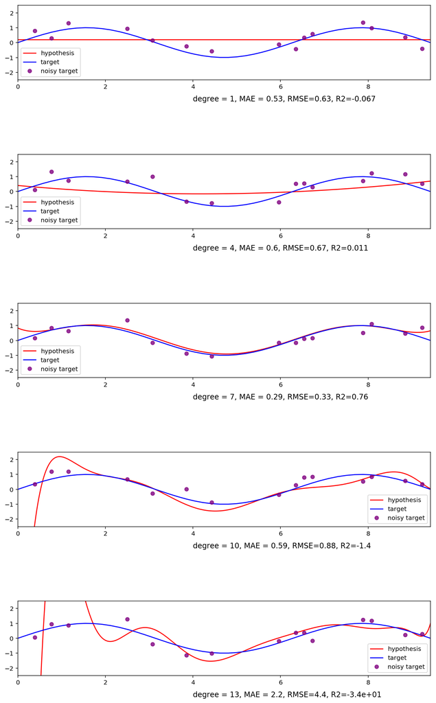

```python
x = np.linspace(0,3*np.pi,50)
N = 15
shuff = np.random.permutation(len(x))
x_pts = np.array(sorted(x[shuff][:N]))

numfigs = 5
fig,axes = plt.subplots(5,1,figsize=(12,4*numfigs))

plt.subplots_adjust(hspace=1)


for i,deg in enumerate(range(1,numfigs*3+1,3)):
    X = np.ones(N*deg).reshape(N,deg)
    for j in range(1,deg):
        X[:,j] = x_pts**j


    noise = np.random.randn(N)
    y = np.sin(x_pts)+ noise/3

    w = wt_by_deg[deg]


    g = linear_predict(X,w)

    xx = np.linspace(0,np.pi*3,10000)
    h = np.zeros(len(xx))
    for j in range(deg):
        h += w[j]*xx**j

    axes[i].plot(xx,h,label="hypothesis",c='red')

    axes[i].plot(x,np.sin(x),label="target",c='blue')
    axes[i].plot(x_pts,y,'o',label="noisy target",alpha=0.8,c='purple')
    axes[i].legend()
    ymax = 2.5
    ymin = -2.5
    axes[i].axis([0,3*np.pi,ymin,ymax])

    text = axes[i].text(4,ymin-1.3,f"degree = {deg}, MAE = {MAE(g,y):0.2}, RMSE={RMSE(g,y):0.2}, R2={R2(g,y):0.2}", size=12,
    verticalalignment='center')
plt.show()
```

#### Part 6

Below is part of a function that produces a test/train split on a dataset $\mathcal{D}$.

Fill in the missing parts of the function in the following way using array slicing.

`X_train` should be the first "`cutoff`" many elements in the shuffled matrix `X2`.

`X_test` should be the remaining elements in `X2`.

`y_train` should be the first "`cutoff`" many elements in the shuffled matrix `y2`.

`y_test` should be the remaining elements in `y2`.

```python
def test_train_split(X,y,train_percent=0.8,rand_seed=42):
    np.random.seed(rand_seed)
    cutoff = int(train_percent*X.shape[0])
    shuff = np.random.permutation(X.shape[0])
    X2 = X[shuff]
    y2 = y[shuff]
   ##### Your code
    return X_train,X_test,y_train,y_test
```

#### Part 7

Suppose we have a dataset $\mathcal{D}$ in a regression problem.

1. What will happen to the in-sample error of linear regression using polynomials of degree $d$ as $d \to \infty$?
2. What will happen to the out-of-sample error of linear regression as $d$ increases?

You can use the output of the code below to help you form your answer.

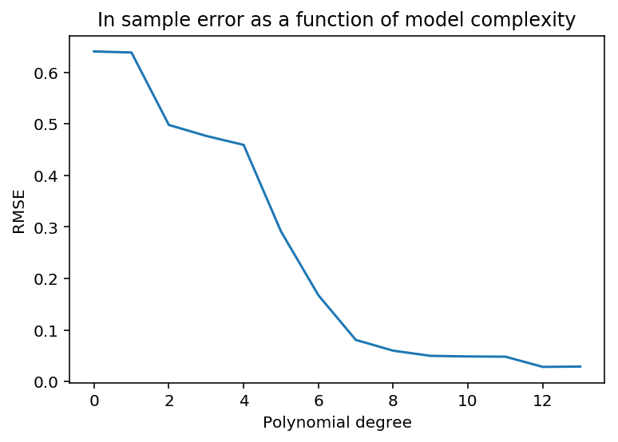

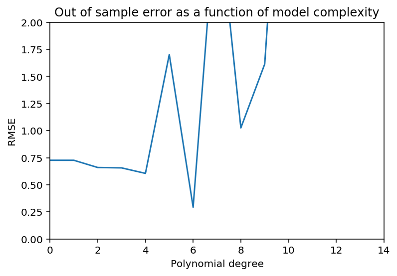

```python
xmin,xmax = 0,4*np.pi
x = np.linspace(xmin,xmax,1000)
D = 14

N = 100
shuff = np.random.permutation(len(x))
x_pts = np.array(sorted(x[shuff][:N]))

K = 200
train_vals = np.zeros(D*K).reshape(K,D)
test_vals = np.zeros(D*K).reshape(K,D)
noise = np.random.randn(N)
y = np.sin(x_pts)+ noise/7

for k in range(K):
    shuff = np.random.permutation(len(x))
    x_pts = np.array(sorted(x[shuff][:N]))
    noise = np.random.randn(N)
    y = np.sin(x_pts)+ noise/7
    for i,deg in enumerate(range(D)):
        X = np.ones(N*deg).reshape(N,deg)
        for j in range(1,deg):
            X[:,j] = x_pts**j
        X_train,X_test,y_train,y_test = test_train_split(X,y,0.13)

        w = linear_fit(X_train,y_train)

        g_train = linear_predict(X_train,w)
        g_test = linear_predict(X_test,w)

        r_train = RMSE(g_train,y_train)
        r_test = RMSE(g_test,y_test)
        train_vals[k][i] = r_train
        test_vals[k][i] = r_test

tr_vals = np.mean(train_vals,axis=0)
te_vals = np.mean(test_vals,axis=0)

plt.plot(range(D),tr_vals)
plt.title("In sample error as a function of model complexity")
plt.xlabel("Polynomial degree")
plt.ylabel("RMSE")
plt.show()
plt.title("Out of sample error as a function of model complexity")
plt.plot(range(D),te_vals)
plt.xlabel("Polynomial degree")
plt.ylabel("RMSE")

plt.axis([0,D,0,2])
plt.show()
```

#### Part 8

In your answer to part 7 you hopefully observed that training error should strictly decrease as the degree of the hypothesis polynomials increases. That is because any high degree polynomial can "simulate" a lower degree polynomial by making it's high order coefficients zero. Thus nothing is lost and something might be gained by increasing the degree.

But the code below shows that in-sample error actually starts to increase on our dataset for polynomials of very high degree. Why do you think this happens?

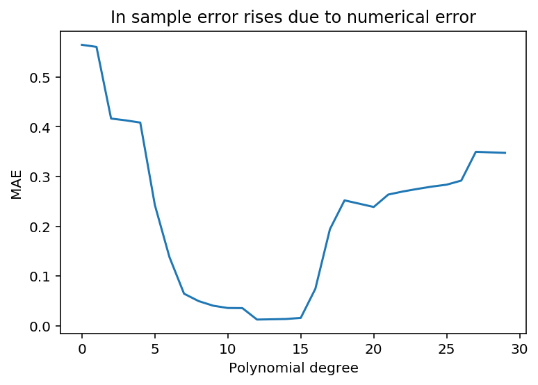

```python
## Numerical error

xmin,xmax = 0,4*np.pi
x = np.linspace(xmin,xmax,1000)
D = 30

N = 100
shuff = np.random.permutation(len(x))
x_pts = np.array(sorted(x[shuff][:N]))

K = 200
train_vals = np.zeros(D*K).reshape(K,D)
test_vals = np.zeros(D*K).reshape(K,D)
noise = np.random.randn(N)
y = np.sin(x_pts)+ noise/7

for k in range(K):
    shuff = np.random.permutation(len(x))
    x_pts = np.array(sorted(x[shuff][:N]))
    noise = np.random.randn(N)
    y = np.sin(x_pts)+ noise/7
    for i,deg in enumerate(range(D)):
        X = np.ones(N*deg).reshape(N,deg)
        for j in range(1,deg):
            X[:,j] = x_pts**j
        X_train,X_test,y_train,y_test = test_train_split(X,y,0.13)

        w = linear_fit(X_train,y_train)

        g_train = linear_predict(X_train,w)
        g_test = linear_predict(X_test,w)

        r_train = MAE(g_train,y_train)
        r_test = MAE(g_test,y_test)
        train_vals[k][i] = r_train
        test_vals[k][i] = r_test

tr_vals = np.mean(train_vals,axis=0)
te_vals = np.mean(test_vals,axis=0)

plt.plot(range(D),tr_vals)
plt.title("In sample error rises due to numerical error")
plt.xlabel("Polynomial degree")
plt.ylabel("MAE")

#plt.axis([0,D,0,2])
plt.show()
```

#### Part 9

Adjust the `deg` (degree) variable in the code below such that the hypothesis space best suits the data and target function. The graphic should be helpful. Consider whether you want to revise your answer for Part 7 pt 2.

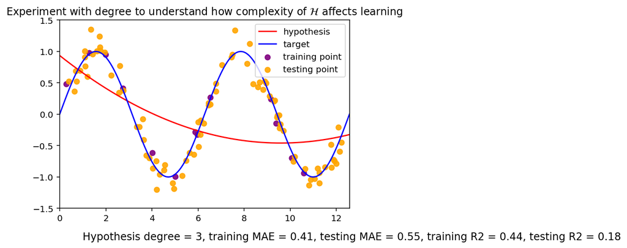

```python
shuff = np.random.permutation(len(x))
x_pts = np.array(sorted(x[shuff][:N]))

deg = 3  ## The degree of the polynomials in the hypothesis space

noise = np.random.randn(N)
y = np.sin(x_pts) + noise/7
yy = np.sin(x)

X = np.ones(N*deg).reshape(N,deg)
for j in range(1,deg):
    X[:,j] = x_pts**j

X_train,X_test,y_train,y_test = test_train_split(X,y,0.13)




w = linear_fit(X_train,y_train)
g_train = linear_predict(X_train,w)
g_test = linear_predict(X_test,w)

xx = np.linspace(0,xmax,10000)
h = np.zeros(len(xx))
for j in range(deg):
    h += w[j]*xx**j

plt.plot(xx,h,label="hypothesis",c='red')

plt.plot(x,yy,label="target",c='blue')
plt.title(r"Experiment with degree to understand how complexity of $\mathcal{H}$ affects learning")
plt.scatter(X_train[:,1],y_train,c='purple',label="training point",alpha=0.9)
plt.scatter(X_test[:,1],y_test,c='orange',label="testing point",alpha=0.9)
plt.legend()

ymax = 1.5
ymin = -1.5#np.min(X[:,1])*1.15
plt.axis([xmin,xmax,ymin,ymax])
plt.text((xmax-xmin)//8,ymin*1.3,f"Hypothesis degree = {deg}, training MAE = {MAE(g_train,y_train):0.2}, testing MAE = {MAE(g_test,y_test):0.2}, training R2 = {R2(g_train,y_train):0.2}, testing R2 = {R2(g_test,y_test):0.2}", size=12,
    verticalalignment='center')
plt.show()
```

### Learning Curves

In the above exercises we fixed a dataset and explored what happens as we vary the complexity of the hypothesis class $\mathcal{H}$.

Now we will fix a hypothesis class $\mathcal{H}$ and explore what happens to training and testing error as the number of datapoints increases. This is known as a [Learning Curve](https://www.coursera.org/lecture/machine-learning/learning-curves-Kont7).

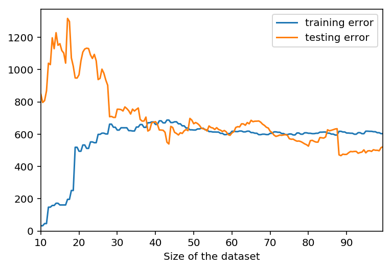

```python
x = np.linspace(0,17*np.pi,2000)
N = 200
shuff = np.random.permutation(len(x))
x_pts = np.array(sorted(x[shuff][:N]))

deg =6
X = np.ones(N*deg).reshape(N,deg)
for j in range(1,deg):
    X[:,j] = x_pts**j

shuff = np.random.permutation(N)
X = X[shuff]


noise = np.random.randn(N)
y = np.sin(x_pts)*x_pts**2 + noise
y2 = y[shuff]

values = []
for m in range(10,N):
    X_train = X[:int(m*0.5)]
    X_test = X[int(m*0.5):m]

    y_train = y2[:int(m*0.5)]
    y_test = y2[int(m*0.5):m]



    w = linear_fit(X_train,y_train)


    g_train = linear_predict(X_train,w)
    g_test = linear_predict(X_test,w)

    r_train = MAE(g_train,y_train)
    r_test = MAE(g_test,y_test)
    values.append([m,r_train,r_test])

values = np.array(values)
plt.plot(values[:,0]/2,values[:,1],label="training error")
plt.plot(values[:,0]/2,values[:,2],label="testing error")
xmin = np.min(values[:,0])
xmax = np.max(values[:,0])
ymin = 0
ymax = np.max(values[:,1])*2
plt.axis([xmin,xmax/2,ymin,ymax])
plt.xlabel("Size of the dataset")
plt.legend()
plt.show()
```

### That looks a bit rough...

The shape of the above curves depend on random choices and may not look quite like the ideal.

The picture should be approximately this:

[figure not shown]

In the code below we average the above experiment over $K=200$ runs and get something that looks more appropriate.

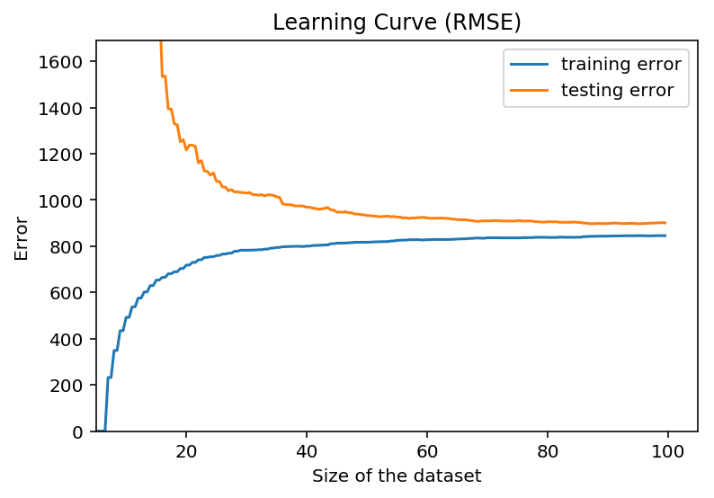

```python
K = 200
testvals = np.zeros((N-10)*K).reshape(K,N-10)
trainvals = np.zeros((N-10)*K).reshape(K,N-10)

for k in range(K):
    shuff = np.random.permutation(N)
    X = X[shuff]
    y = y[shuff]
    for m in range(10,N):
        X_train = X[:int(m*0.5)]
        X_test = X[int(m*0.5):m]

        y_train = y[:int(m*0.5)]
        y_test = y[int(m*0.5):m]




        w = linear_fit(X_train,y_train)


        g_train = linear_predict(X_train,w)
        g_test = linear_predict(X_test,w)

        r_train = RMSE(g_train,y_train)
        r_test = RMSE(g_test,y_test)
        testvals[k,m-10] = r_test
        trainvals[k,m-10] = r_train
testy = np.mean(testvals,axis=0)
trainy = np.mean(trainvals,axis=0)
plt.plot(np.arange(10,N)/2,trainy,label="training error")
plt.plot(np.arange(10,N)/2,testy,label="testing error")
xmin = 5
xmax = N/2+5
ymin = 0
ymax = np.max(trainy)*2
plt.axis([xmin,xmax,ymin,ymax])
plt.xlabel("Size of the dataset")
plt.ylabel("Error")
plt.legend()
plt.title("Learning Curve (RMSE)")
plt.show()
```

### Part 10

1. What does the learning curve look like when the hypothesis class is too complex for the target function and the amount of data?
2. What does the learning curve look like when the hypothesis class is too simple for the target function and the amount of data?
3. What does the learning curve look like if the complexity of the hypothesis class is appropriate to the problem?
4. Why does test error go down and train error go up?

### Regression meets classification

In this final section we connect regression and classification.

First we reproduce the linearly separable dataset that we used in HW 2.

Then we embed that data in 3D space by making the $z$-coordinate of each data point 1 for positive examples, and -1 for negative examples.

Finally we fit this 3D data with a plane using linear regression.

All of this is shown in the plot way down below.

#### Part 11

How can this regression plane $z = a+bx+cy$ be used to help classify new data points?

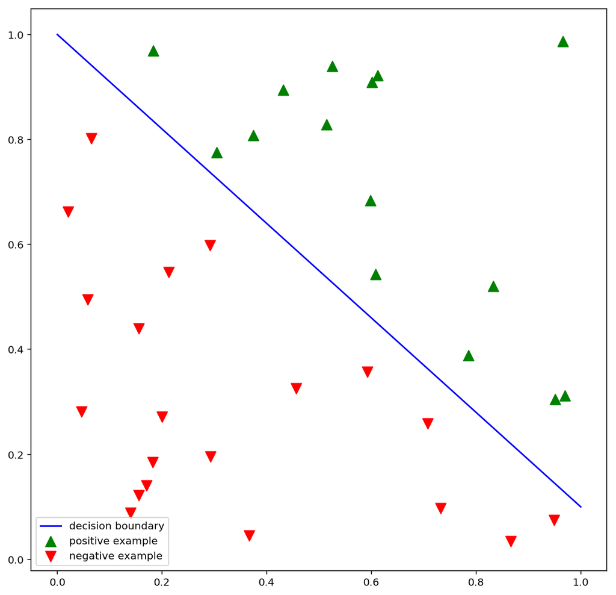

```python
## Producing synthetic data
"""
In this cell we create 35 points at random.
We separate them with a line to create linearly separable data.
The data is stored in the points array.
Note that the first column of the points array is a "bias" column of all ones.
The "line _coef" (coefficients) variable works like this:
    if line_coef = (a,b,c)
    then this describes the line
    0 = a + bx + cy
This line can be thought of as the intersection of the plane
    z = a + bx + cy
with the xy plane.
Observe that in
    0 = a + bx + cy
there are really only two degrees of freedom, because we can divide everything by c to get

    0 = A + Bx + y
where A = a/c and B = b/c.
(This assumes c != 0, but this assumption will almost always be true.)
"""

import numpy as np
import matplotlib.pyplot as plt

N = 35 # number of points
np.random.seed(42)  # So that everyone has the same "random" points
points = np.zeros(3*N).reshape(N,3)
points[:,1] = np.random.rand(N) #random x-coordinates
points[:,2] = np.random.rand(N) #random y-coordinates
points[:,0] = np.ones(N)        #bias column

line_coef = (-1,0.9,1)          #this line will define whether a point is a positive or negative example
pos = points.dot(line_coef) >= 0  # positive examples are above the line
neg = ~pos   # negative examples are below the line
"""
Question:  do you understand what pos and neg are, and how they work?
           you might want to print them out and experiment with them.
           we use them to select out certain rows of a numpy array.
           if this is confusing read the section here about
           Boolean or "mask" index arrays:
           https://docs.scipy.org/doc/numpy-1.10.0/user/basics.indexing.html
"""


x = np.linspace(0,1)                # domain of decision boundary line
y = -line_coef[1]*x - line_coef[0]  # this is the decision boundary line

"""
A note about colors... I used "green" for "positive example" and "red" for "negative example".
If you happen to be red green colorblind (like 8% of all men) then please feel free to change the colors.
"""

plt.figure(1,figsize=(10,10))
plt.scatter(points[pos,1],points[pos,2],c='green',marker="^",s=100,label="positive example")  #plot positive examples
plt.scatter(points[neg,1],points[neg,2],c='red',marker="v",s=100,label="negative example")  #plot negative examples
plt.plot(x,y,'b',label="decision boundary")  #plot linear separator
plt.legend()
plt.show()
```

```python
y = np.ones(N)
y[neg] = -1
y[pos] = 1
X = points

w = linear_fit(X,y)
X.shape
Pos =X[pos]
Neg = X[neg]
```

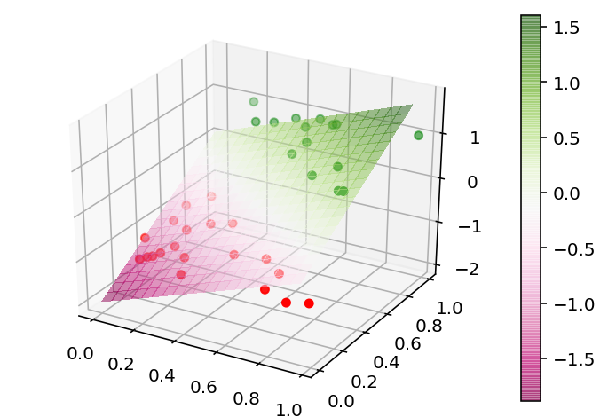

```python
from mpl_toolkits.mplot3d import Axes3D
import matplotlib.pyplot as plt
from matplotlib import cm
from matplotlib.ticker import LinearLocator, FormatStrFormatter
import numpy as np


fig = plt.figure()
#ax = fig.gca(projection='3d')

ax = plt.axes(projection='3d')


# Make data.
XX = np.arange(0, 1, 0.05)
YY = np.arange(0, 1, 0.05)
XX, YY = np.meshgrid(XX, YY)

w = linear_fit(X,y)

Z = w[0]+w[1]*XX+w[2]*YY

surf = ax.plot_surface(XX, YY, Z, cmap=cm.PiYG,
                       linewidth=0, antialiased=False,alpha=0.5)


# Data for three-dimensional scattered points
zdata = np.ones(Pos.shape[0])
xdata = Pos[:,1]
ydata = Pos[:,2]
ax.scatter3D(xdata, ydata, zdata, c='green');

zdata = -1*np.ones(Neg.shape[0])
xdata = Neg[:,1]
ydata = Neg[:,2]
ax.scatter3D(xdata, ydata, zdata, c='red');
fig.colorbar(surf)
plt.show()
```